# ReferenceManager How-To

Peter von Rohr

2018-09-26

This notebook provides some examples on how to work with the package `ReferenceManager` from ropenscie.

## Documentation

The vignette seams to be available from https://arxiv.org/pdf/1403.2036v1.pdf

## Installation

The package is installed via

```r
devtools::install_github("ropensci/RefManageR")
```

## The Plan

The set of tools and functionalities described here should allow for parallelized authoring of the same document by many people. Each author should have a separate working copy and a local git-repository. At any time it should be possible to build the whole document by all authors without changing the source code of the document manually.

Based on these requirements the following properties must be satisfied.

- At least one author must have access to a reference manager database where all cited literature items are stored
- The reference manager allows to export a .bib-file containing a complete list of all cited literature items
- The bibliography file must have the same name for all authors
- The bibliography file must be versioned by git and must be pushed to the remote repository. This allows for a build of the complete document for anybody who does not have access to the central reference database

The following parameters are different for all authors

- The path to the .bib-file that was exported from the reference manager.

## Examples and Tests

Working through the examples in the vignette leads to

```r
s_bib_file <- system.file("Bib", "biblatexExamples.bib", package = "RefManageR")
stopifnot(file.exists(s_bib_file))
bib <- RefManageR::ReadBib(s_bib_file, check = FALSE)
print(bib[c("cms", "jcg", "ctan")], .opts = list(check.entries = FALSE))
```

```
[1] _The Chicago Manual of Style. The Essential Guide for Writers, Editors, and Publishers_. 15th ed. Chicago, Ill.: University of Chicago Press, 2003. ISBN: 0-226-10403-6.

[2] _Computers and Graphics_. 35.4 (2011): _Semantic 3D Media and Content_. ISSN: 0097-8493.

[3] _CTAN. The Comprehensive TeX Archive Network_. 2006. <URL: https://www.ctan.org> (visited on 10/01/2006).
```

## Output

Writing some records to a bibfile

```r
RefManageR::BibOptions(check.entries = FALSE)
RefManageR::toBiblatex(bib[c("cms", "jcg", "ctan")])
```

```
@Manual{cms,
  title = {The Chicago Manual of Style},
  date = {2003},
  subtitle = {The Essential Guide for Writers, Editors, and Publishers},
  edition = {15},
  publisher = {University of Chicago Press},
  location = {Chicago, Ill.},
  isbn = {0-226-10403-6},
  label = {CMS},
  langid = {english},
  langidopts = {variant=american},
  sorttitle = {Chicago Manual of Style},
  indextitle = {Chicago Manual of Style, The},
  shorttitle = {Chicago Manual of Style},
  annotation = {This is a \texttt{manual} entry without an \texttt{author} or
                  \texttt{editor}. Note the \texttt{label} field in the database
                  file which is provided for author-year citation styles. Also
                  note the \texttt{sorttitle} and \texttt{indextitle} fields. By
                  default, all entries without an \texttt{author} or
                  \texttt{editor} are alphabetized by \texttt{title} but we want
                  this entry to be alphabetized under \enquote*{C} rather than
                  \enquote*{T}. There's also an \texttt{isbn} field},
}

@Periodical{jcg,
  title = {Computers and Graphics},
  year = {2011},
  issuetitle = {Semantic {3D} Media and Content},
  volume = {35},
  number = {4},
  issn = {0097-8493},
  annotation = {This is a \texttt{periodical} entry with an \texttt{issn}
                  field.},
}

@Online{ctan,
  title = {CTAN},
  date = {2006},
  url = {https://www.ctan.org},
  subtitle = {The Comprehensive TeX Archive Network},
  urldate = {2006-10-01},
  label = {CTAN},
  langid = {english},
  langidopts = {variant=american},
  annotation = {This is an \texttt{online} entry. The \textsc{url}, which is
                  given in the \texttt{url} field, is transformed into a
                  clickable link if \texttt{hyperref} support has been
                  enabled. Note the format of the \texttt{urldate} field
                  (\texttt{yyyy-mm-dd}) in the database file. Also note the
                  \texttt{label} field which may be used as a fallback by
                  citation styles which need an \texttt{author} and\slash or a
                  \texttt{year}},
}
```

```r
# cat(RefManageR::toBiblatex(bib[c("cms", "jcg", "ctan")]), file = "references.bib", sep = "\n")
RefManageR::WriteBib(bib = bib[c("cms", "jcg", "ctan")])
```

```
Writing 3 Bibtex entries ... OK
Results written to file ‘references.bib’
```

Then, we try to use the `citr`-package addin to include citations.

The citations used with `citr` produces the following: (“Semantic 3d Media and Content” 2011).

Yet anoter citation in (“CTAN: The Comprehensive Tex Archive Network” 2006).

A citation with out brackets (*The Chicago Manual of Style: The Essential Guide for Writers, Editors, and Publishers* 2003).

## Working with current document

The analysis of the literature citations requires to read the content of the currently used Rmd-document. One way to determine this is via

```r
(this_file <- rstudioapi::getSourceEditorContext()$path)
```

```
[1] "~/Data/Projects/Github/charlotte-ngs/EarlyMaturityBeef/master/EarlyMaturityBeef/References/rnb/20180926_reference_manager.Rmd"
```

See https://stackoverflow.com/questions/47044068/get-the-path-of-current-script/47045368 for more details.

## Figure and Tables

References to figures and tables must not be listed as literature content.

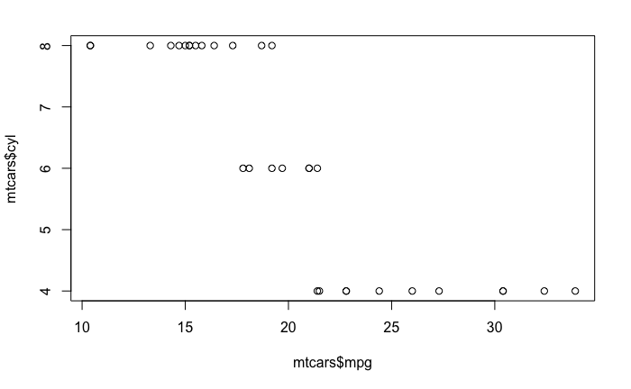

```r
plot(mtcars$mpg, mtcars$cyl)
```

## References

“CTAN: The Comprehensive Tex Archive Network.” 2006. https://www.ctan.org.

“Semantic 3d Media and Content.” 2011. *Computers and Graphics* 35 (4).

*The Chicago Manual of Style: The Essential Guide for Writers, Editors, and Publishers*. 2003. 15th ed. Chicago, Ill.: University of Chicago Press.